# Data 558 Homework 1

Cathy Jia

Due April 12, 2019 by 11:59pm

```python
from IPython.core.interactiveshell import InteractiveShell
InteractiveShell.ast_node_interactivity = "all"
```

# 1

**Read Chapter 2 in Elements of Statistical Learning.**

# 2

**Explain whether each scenario is a classification or regression problem, and indicate whether we are most interested in inference or prediction. Finally, provide n and p.**

### (a)

This is a classification problem and we are most interested in prediction. Our task is to predict a qualitative output in this scenario. We are going to figure out whether a particular customer will click on an online advertisement or not.

n = 200

p = 4

### (b)

This is a regression problem and we are most interested in prediction. The task is to predict the final score by the end of quarter, which is a quantitative output.

n = 20

p = 3

### (c)

n = 300

p = 5

# 3

**In this problem you will brainstorm real-life applications for statistical learning. Your answers aren’t allowed to be the same as any of the examples in the other homework problems.**

### (a) Classification

- **Political Science**

  Classification can be applied in predicting the US president election result. The qualitative response is whether a candidate can be elected as a president or not. The predictors can be whether the candidate was a president in the past or not, number of votes, number of political events attended. etc. This is a prediction problem.
- **Sports**

  Classification can be applied in predicting the FIFA World Cup game results. The team managers can build a classification model to make corresponding plans or strategies to win the matches. This is a prediction application. The qualitative response is the game result: Win, lose or draw. The predictors can be each players' performance score, number of goals, number of cards, number of players taking penalty, and historical game results of this team and the opponent team.
- **Housing**

  Classification can be applied in determine which listing factors affect Airbnb hosts to become Superhosts. The qualitative response is whether a host can become a Superhost. The predictors can be listing location, listing price, room types, amentities (WiFi, kitchen, TV, etc.), how long the host has hosted Airbnb listings, number of reviews, review scores. This is an inference problem.

### (b) Regression

- **Engineering**

  Regression is widely applied in mechanical engineering, chemical engineering, civil engineering, etc. For example, a simple linear regression model is used in predicting the thermal expansion of steel. The quantitative response is the coefficient of thermal expansion of steel. The predictor is temperature. This is a prediction problem.
- **Business**

  In business analytics, regression is very useful in risk prediction or market forecast based on past buying behaviors. One application of regression is to analyze the future customer demands in a supermarket, so manager can better arrange how many items in stock. The quantitative response is how many items customers will buy. The predictors can be item category, customer job, daily number of customers, seasonal number of customers, holiday or not, whether a member or not, etc. This is a prediction application.
- **Economics**

  Regression can be applied in predicting the monthly GDP growth for a country. The quantitative response can be the annual growth rate of GDP per capita. The predictors can be any factors affecting GDP, such as income, human development, education, import, export, govornment spending and population. This is a prediction problem.

### (c) Cluster

- **Education**

  Clustering is useful in providing more insights for educational researches and improving education qualities. Researchers can do clustering on students' academic performance for students with difference background. For example, students grow in urban area are compared with those who from rural area. Students have different performance in one group learning in real classrooms and the other group taking online courses. K-means clustering are usually used in grouping students or questionnaires categorically.
- **Meteorology**

  Clustering is useful in meteorology when researchers need to analyze climate and weather. K-means clustering and hierarchical clustering are applied to meteorological data set to categorize the extent of wind phenomena or rainfall based on different climate variables: humidity, atmospheric pressure, temperature and other meteorological variables in certain regions and time.
- **Bioinformatics**

  Clustering is very useful in bioinformatics. Clustering is especially important in gene analysis and prediction. Researchers and scientists can be used to predict which human body organism an extracted gene is blonging to, or to infer correlations between different genes from different species and deeply cluster the genes into corresponding species.

# 4

**The table below provides a training data set containing six observations, three predictors, and one qualitative response variable. Suppose we wish to use this data set to make a prediction for Y when $X_1$ = $X_2$ = $X_3$ = 0 using K-nearest neighbors.**

```python
import pandas as pd
import numpy as np
data = [[0,4,0,'Green'], [2,0,1,'Red'], [0,1,3,'Red'],[-1,1,2,'Green'],[-3,0,1,'Green'],[2,0,1,'Red']]
df = pd.DataFrame(data, columns = ['X1','X2','X3','Y'])
df
```

|  | X1 | X2 | X3 | Y |
| --- | --- | --- | --- | --- |
| 0 | 0 | 4 | 0 | Green |
| 1 | 2 | 0 | 1 | Red |
| 2 | 0 | 1 | 3 | Red |
| 3 | -1 | 1 | 2 | Green |
| 4 | -3 | 0 | 1 | Green |
| 5 | 2 | 0 | 1 | Red |

### (a)

**Compute the Euclidean distance between each observation and the test point $X_1$ = $X_2$ = $X_3$ = 0.**

```python
df['euclidean_distance'] = df[['X1','X2','X3']].sub(np.array([[0,0,0]])).pow(2).sum(1).pow(0.5)
df
```

|  | X1 | X2 | X3 | Y | euclidean_distance |
| --- | --- | --- | --- | --- | --- |
| 0 | 0 | 4 | 0 | Green | 4.000000 |
| 1 | 2 | 0 | 1 | Red | 2.236068 |
| 2 | 0 | 1 | 3 | Red | 3.162278 |
| 3 | -1 | 1 | 2 | Green | 2.449490 |
| 4 | -3 | 0 | 1 | Green | 3.162278 |
| 5 | 2 | 0 | 1 | Red | 2.236068 |

### (b)

**What is our prediction with K = 1? Why?**

To answer this question, we first sort the data frame by Euclidean distance.

```python
df.sort_values('euclidean_distance')
```

|  | X1 | X2 | X3 | Y | euclidean_distance |
| --- | --- | --- | --- | --- | --- |
| 1 | 2 | 0 | 1 | Red | 2.236068 |
| 5 | 2 | 0 | 1 | Red | 2.236068 |
| 3 | -1 | 1 | 2 | Green | 2.449490 |
| 2 | 0 | 1 | 3 | Red | 3.162278 |
| 4 | -3 | 0 | 1 | Green | 3.162278 |
| 0 | 0 | 4 | 0 | Green | 4.000000 |

When K = 1, we choose the 1-nearest observation to the test point $X_1$ = $X_2$ = $X_3$ = 0, observation 1 (2, 0, 1, Red). So our prediction with K = 1 is Red.

### (c)

**What is our prediction with K = 3? Why?**

When K = 1, we choose the 3-nearest observations to the test point $X_1$ = $X_2$ = $X_3$ = 0, observation 1 (2, 0, 1, Red), observation 5 (2, 0, 1, Red) and observation 3 (-1, 1, 2, Green) . We choose the major Y, Red. So for our prediction with K = 3 is Red.

### (d)

# 5

**This exercise relates to the College data set, which can be found here http://www-bcf.usc.edu/~gareth/ISL/College.csv. It contains a number of variables for 777 different universities and colleges in the US.**

### (a)

**Use the `pandas.read_csv()` function to read the data into Python. Call the loaded data `college`.**

```python
import pandas as pd
import matplotlib.pyplot as plt
college = pd.read_csv("college.csv", sep=',', header=0)
```

### (b)

```python
college.head(5)
```

|  | Unnamed: 0 | Private | Apps | Accept | Enroll | Top10perc | Top25perc | F.Undergrad | P.Undergrad | Outstate | Room.Board | Books | Personal | PhD | Terminal | S.F.Ratio | perc.alumni | Expend | Grad.Rate |
| --- | --- | --- | --- | --- | --- | --- | --- | --- | --- | --- | --- | --- | --- | --- | --- | --- | --- | --- | --- |
| 0 | Abilene Christian University | Yes | 1660 | 1232 | 721 | 23 | 52 | 2885 | 537 | 7440 | 3300 | 450 | 2200 | 70 | 78 | 18.1 | 12 | 7041 | 60 |
| 1 | Adelphi University | Yes | 2186 | 1924 | 512 | 16 | 29 | 2683 | 1227 | 12280 | 6450 | 750 | 1500 | 29 | 30 | 12.2 | 16 | 10527 | 56 |
| 2 | Adrian College | Yes | 1428 | 1097 | 336 | 22 | 50 | 1036 | 99 | 11250 | 3750 | 400 | 1165 | 53 | 66 | 12.9 | 30 | 8735 | 54 |
| 3 | Agnes Scott College | Yes | 417 | 349 | 137 | 60 | 89 | 510 | 63 | 12960 | 5450 | 450 | 875 | 92 | 97 | 7.7 | 37 | 19016 | 59 |
| 4 | Alaska Pacific University | Yes | 193 | 146 | 55 | 16 | 44 | 249 | 869 | 7560 | 4120 | 800 | 1500 | 76 | 72 | 11.9 | 2 | 10922 | 15 |

```python
college.rename(columns={'Unnamed: 0': 'School'}, inplace=True)
college.set_index('School')
```

| School | Private | Apps | Accept | Enroll | Top10perc | Top25perc | F.Undergrad | P.Undergrad | Outstate | Room.Board | Books | Personal | PhD | Terminal | S.F.Ratio | perc.alumni | Expend | Grad.Rate |
| --- | --- | --- | --- | --- | --- | --- | --- | --- | --- | --- | --- | --- | --- | --- | --- | --- | --- | --- |
| Abilene Christian University | Yes | 1660 | 1232 | 721 | 23 | 52 | 2885 | 537 | 7440 | 3300 | 450 | 2200 | 70 | 78 | 18.1 | 12 | 7041 | 60 |
| Adelphi University | Yes | 2186 | 1924 | 512 | 16 | 29 | 2683 | 1227 | 12280 | 6450 | 750 | 1500 | 29 | 30 | 12.2 | 16 | 10527 | 56 |
| Adrian College | Yes | 1428 | 1097 | 336 | 22 | 50 | 1036 | 99 | 11250 | 3750 | 400 | 1165 | 53 | 66 | 12.9 | 30 | 8735 | 54 |
| Agnes Scott College | Yes | 417 | 349 | 137 | 60 | 89 | 510 | 63 | 12960 | 5450 | 450 | 875 | 92 | 97 | 7.7 | 37 | 19016 | 59 |
| Alaska Pacific University | Yes | 193 | 146 | 55 | 16 | 44 | 249 | 869 | 7560 | 4120 | 800 | 1500 | 76 | 72 | 11.9 | 2 | 10922 | 15 |
| Albertson College | Yes | 587 | 479 | 158 | 38 | 62 | 678 | 41 | 13500 | 3335 | 500 | 675 | 67 | 73 | 9.4 | 11 | 9727 | 55 |
| Albertus Magnus College | Yes | 353 | 340 | 103 | 17 | 45 | 416 | 230 | 13290 | 5720 | 500 | 1500 | 90 | 93 | 11.5 | 26 | 8861 | 63 |
| Albion College | Yes | 1899 | 1720 | 489 | 37 | 68 | 1594 | 32 | 13868 | 4826 | 450 | 850 | 89 | 100 | 13.7 | 37 | 11487 | 73 |
| Albright College | Yes | 1038 | 839 | 227 | 30 | 63 | 973 | 306 | 15595 | 4400 | 300 | 500 | 79 | 84 | 11.3 | 23 | 11644 | 80 |
| Alderson-Broaddus College | Yes | 582 | 498 | 172 | 21 | 44 | 799 | 78 | 10468 | 3380 | 660 | 1800 | 40 | 41 | 11.5 | 15 | 8991 | 52 |
| Alfred University | Yes | 1732 | 1425 | 472 | 37 | 75 | 1830 | 110 | 16548 | 5406 | 500 | 600 | 82 | 88 | 11.3 | 31 | 10932 | 73 |
| Allegheny College | Yes | 2652 | 1900 | 484 | 44 | 77 | 1707 | 44 | 17080 | 4440 | 400 | 600 | 73 | 91 | 9.9 | 41 | 11711 | 76 |
| Allentown Coll. of St. Francis de Sales | Yes | 1179 | 780 | 290 | 38 | 64 | 1130 | 638 | 9690 | 4785 | 600 | 1000 | 60 | 84 | 13.3 | 21 | 7940 | 74 |
| Alma College | Yes | 1267 | 1080 | 385 | 44 | 73 | 1306 | 28 | 12572 | 4552 | 400 | 400 | 79 | 87 | 15.3 | 32 | 9305 | 68 |
| Alverno College | Yes | 494 | 313 | 157 | 23 | 46 | 1317 | 1235 | 8352 | 3640 | 650 | 2449 | 36 | 69 | 11.1 | 26 | 8127 | 55 |
| American International College | Yes | 1420 | 1093 | 220 | 9 | 22 | 1018 | 287 | 8700 | 4780 | 450 | 1400 | 78 | 84 | 14.7 | 19 | 7355 | 69 |
| Amherst College | Yes | 4302 | 992 | 418 | 83 | 96 | 1593 | 5 | 19760 | 5300 | 660 | 1598 | 93 | 98 | 8.4 | 63 | 21424 | 100 |
| Anderson University | Yes | 1216 | 908 | 423 | 19 | 40 | 1819 | 281 | 10100 | 3520 | 550 | 1100 | 48 | 61 | 12.1 | 14 | 7994 | 59 |
| Andrews University | Yes | 1130 | 704 | 322 | 14 | 23 | 1586 | 326 | 9996 | 3090 | 900 | 1320 | 62 | 66 | 11.5 | 18 | 10908 | 46 |
| Angelo State University | No | 3540 | 2001 | 1016 | 24 | 54 | 4190 | 1512 | 5130 | 3592 | 500 | 2000 | 60 | 62 | 23.1 | 5 | 4010 | 34 |
| Antioch University | Yes | 713 | 661 | 252 | 25 | 44 | 712 | 23 | 15476 | 3336 | 400 | 1100 | 69 | 82 | 11.3 | 35 | 42926 | 48 |
| Appalachian State University | No | 7313 | 4664 | 1910 | 20 | 63 | 9940 | 1035 | 6806 | 2540 | 96 | 2000 | 83 | 96 | 18.3 | 14 | 5854 | 70 |
| Aquinas College | Yes | 619 | 516 | 219 | 20 | 51 | 1251 | 767 | 11208 | 4124 | 350 | 1615 | 55 | 65 | 12.7 | 25 | 6584 | 65 |
| Arizona State University Main campus | No | 12809 | 10308 | 3761 | 24 | 49 | 22593 | 7585 | 7434 | 4850 | 700 | 2100 | 88 | 93 | 18.9 | 5 | 4602 | 48 |
| Arkansas College (Lyon College) | Yes | 708 | 334 | 166 | 46 | 74 | 530 | 182 | 8644 | 3922 | 500 | 800 | 79 | 88 | 12.6 | 24 | 14579 | 54 |
| Arkansas Tech University | No | 1734 | 1729 | 951 | 12 | 52 | 3602 | 939 | 3460 | 2650 | 450 | 1000 | 57 | 60 | 19.6 | 5 | 4739 | 48 |
| Assumption College | Yes | 2135 | 1700 | 491 | 23 | 59 | 1708 | 689 | 12000 | 5920 | 500 | 500 | 93 | 93 | 13.8 | 30 | 7100 | 88 |
| Auburn University-Main Campus | No | 7548 | 6791 | 3070 | 25 | 57 | 16262 | 1716 | 6300 | 3933 | 600 | 1908 | 85 | 91 | 16.7 | 18 | 6642 | 69 |
| Augsburg College | Yes | 662 | 513 | 257 | 12 | 30 | 2074 | 726 | 11902 | 4372 | 540 | 950 | 65 | 65 | 12.8 | 31 | 7836 | 58 |
| Augustana College IL | Yes | 1879 | 1658 | 497 | 36 | 69 | 1950 | 38 | 13353 | 4173 | 540 | 821 | 78 | 83 | 12.7 | 40 | 9220 | 71 |
| ... | ... | ... | ... | ... | ... | ... | ... | ... | ... | ... | ... | ... | ... | ... | ... | ... | ... | ... |
| Westfield State College | No | 3100 | 2150 | 825 | 3 | 20 | 3234 | 941 | 5542 | 3788 | 500 | 1300 | 75 | 79 | 15.7 | 20 | 4222 | 65 |
| Westminster College MO | Yes | 662 | 553 | 184 | 20 | 43 | 665 | 37 | 10720 | 4050 | 600 | 1650 | 66 | 70 | 12.5 | 20 | 7925 | 62 |
| Westminster College | Yes | 996 | 866 | 377 | 29 | 58 | 1411 | 72 | 12065 | 3615 | 430 | 685 | 62 | 78 | 12.5 | 41 | 8596 | 80 |
| Westminster College of Salt Lake City | Yes | 917 | 720 | 213 | 21 | 60 | 979 | 743 | 8820 | 4050 | 600 | 2025 | 68 | 83 | 10.5 | 34 | 7170 | 50 |
| Westmont College | No | 950 | 713 | 351 | 42 | 72 | 1276 | 9 | 14320 | 5304 | 490 | 1410 | 77 | 77 | 14.9 | 17 | 8837 | 87 |
| Wheaton College IL | Yes | 1432 | 920 | 548 | 56 | 84 | 2200 | 56 | 11480 | 4200 | 530 | 1400 | 81 | 83 | 12.7 | 40 | 11916 | 85 |
| Westminster College PA | Yes | 1738 | 1373 | 417 | 21 | 55 | 1335 | 30 | 18460 | 5970 | 700 | 850 | 92 | 96 | 13.2 | 41 | 22704 | 71 |
| Wheeling Jesuit College | Yes | 903 | 755 | 213 | 15 | 49 | 971 | 305 | 10500 | 4545 | 600 | 600 | 66 | 71 | 14.1 | 27 | 7494 | 72 |
| Whitman College | Yes | 1861 | 998 | 359 | 45 | 77 | 1220 | 46 | 16670 | 4900 | 750 | 800 | 80 | 83 | 10.5 | 51 | 13198 | 72 |
| Whittier College | Yes | 1681 | 1069 | 344 | 35 | 63 | 1235 | 30 | 16249 | 5699 | 500 | 1998 | 84 | 92 | 13.6 | 29 | 11778 | 52 |
| Whitworth College | Yes | 1121 | 926 | 372 | 43 | 70 | 1270 | 160 | 12660 | 4500 | 678 | 2424 | 80 | 80 | 16.9 | 20 | 8328 | 80 |
| Widener University | Yes | 2139 | 1492 | 502 | 24 | 64 | 2186 | 2171 | 12350 | 5370 | 500 | 1350 | 88 | 86 | 12.6 | 19 | 9603 | 63 |
| Wilkes University | Yes | 1631 | 1431 | 434 | 15 | 36 | 1803 | 603 | 11150 | 5130 | 550 | 1260 | 78 | 92 | 13.3 | 24 | 8543 | 67 |
| Willamette University | Yes | 1658 | 1327 | 395 | 49 | 80 | 1595 | 159 | 14800 | 4620 | 400 | 790 | 91 | 94 | 13.3 | 37 | 10779 | 68 |
| William Jewell College | Yes | 663 | 547 | 315 | 32 | 67 | 1279 | 75 | 10060 | 2970 | 500 | 2600 | 74 | 80 | 11.2 | 19 | 7885 | 59 |
| William Woods University | Yes | 469 | 435 | 227 | 17 | 39 | 851 | 120 | 10535 | 4365 | 550 | 3700 | 39 | 66 | 12.9 | 16 | 7438 | 52 |
| Williams College | Yes | 4186 | 1245 | 526 | 81 | 96 | 1988 | 29 | 19629 | 5790 | 500 | 1200 | 94 | 99 | 9.0 | 64 | 22014 | 99 |
| Wilson College | Yes | 167 | 130 | 46 | 16 | 50 | 199 | 676 | 11428 | 5084 | 450 | 475 | 67 | 76 | 8.3 | 43 | 10291 | 67 |
| Wingate College | Yes | 1239 | 1017 | 383 | 10 | 34 | 1207 | 157 | 7820 | 3400 | 550 | 1550 | 69 | 81 | 13.9 | 8 | 7264 | 91 |
| Winona State University | No | 3325 | 2047 | 1301 | 20 | 45 | 5800 | 872 | 4200 | 2700 | 300 | 1200 | 53 | 60 | 20.2 | 18 | 5318 | 58 |
| Winthrop University | No | 2320 | 1805 | 769 | 24 | 61 | 3395 | 670 | 6400 | 3392 | 580 | 2150 | 71 | 80 | 12.8 | 26 | 6729 | 59 |
| Wisconsin Lutheran College | Yes | 152 | 128 | 75 | 17 | 41 | 282 | 22 | 9100 | 3700 | 500 | 1400 | 48 | 48 | 8.5 | 26 | 8960 | 50 |
| Wittenberg University | Yes | 1979 | 1739 | 575 | 42 | 68 | 1980 | 144 | 15948 | 4404 | 400 | 800 | 82 | 95 | 12.8 | 29 | 10414 | 78 |
| Wofford College | Yes | 1501 | 935 | 273 | 51 | 83 | 1059 | 34 | 12680 | 4150 | 605 | 1440 | 91 | 92 | 15.3 | 42 | 7875 | 75 |
| Worcester Polytechnic Institute | Yes | 2768 | 2314 | 682 | 49 | 86 | 2802 | 86 | 15884 | 5370 | 530 | 730 | 92 | 94 | 15.2 | 34 | 10774 | 82 |
| Worcester State College | No | 2197 | 1515 | 543 | 4 | 26 | 3089 | 2029 | 6797 | 3900 | 500 | 1200 | 60 | 60 | 21.0 | 14 | 4469 | 40 |
| Xavier University | Yes | 1959 | 1805 | 695 | 24 | 47 | 2849 | 1107 | 11520 | 4960 | 600 | 1250 | 73 | 75 | 13.3 | 31 | 9189 | 83 |
| Xavier University of Louisiana | Yes | 2097 | 1915 | 695 | 34 | 61 | 2793 | 166 | 6900 | 4200 | 617 | 781 | 67 | 75 | 14.4 | 20 | 8323 | 49 |
| Yale University | Yes | 10705 | 2453 | 1317 | 95 | 99 | 5217 | 83 | 19840 | 6510 | 630 | 2115 | 96 | 96 | 5.8 | 49 | 40386 | 99 |
| York College of Pennsylvania | Yes | 2989 | 1855 | 691 | 28 | 63 | 2988 | 1726 | 4990 | 3560 | 500 | 1250 | 75 | 75 | 18.1 | 28 | 4509 | 99 |

777 rows × 18 columns

### (c)

#### i.

**Use the `describe` attribute to produce a numerical summary of the variables in the data set.**

```python
college.describe()
```

|  | Apps | Accept | Enroll | Top10perc | Top25perc | F.Undergrad | P.Undergrad | Outstate | Room.Board | Books | Personal | PhD | Terminal | S.F.Ratio | perc.alumni | Expend | Grad.Rate |
| --- | --- | --- | --- | --- | --- | --- | --- | --- | --- | --- | --- | --- | --- | --- | --- | --- | --- |
| count | 777.000000 | 777.000000 | 777.000000 | 777.000000 | 777.000000 | 777.000000 | 777.000000 | 777.000000 | 777.000000 | 777.000000 | 777.000000 | 777.000000 | 777.000000 | 777.000000 | 777.000000 | 777.000000 | 777.00000 |
| mean | 3001.638353 | 2018.804376 | 779.972973 | 27.558559 | 55.796654 | 3699.907336 | 855.298584 | 10440.669241 | 4357.526384 | 549.380952 | 1340.642214 | 72.660232 | 79.702703 | 14.089704 | 22.743887 | 9660.171171 | 65.46332 |
| std | 3870.201484 | 2451.113971 | 929.176190 | 17.640364 | 19.804778 | 4850.420531 | 1522.431887 | 4023.016484 | 1096.696416 | 165.105360 | 677.071454 | 16.328155 | 14.722359 | 3.958349 | 12.391801 | 5221.768440 | 17.17771 |
| min | 81.000000 | 72.000000 | 35.000000 | 1.000000 | 9.000000 | 139.000000 | 1.000000 | 2340.000000 | 1780.000000 | 96.000000 | 250.000000 | 8.000000 | 24.000000 | 2.500000 | 0.000000 | 3186.000000 | 10.00000 |
| 25% | 776.000000 | 604.000000 | 242.000000 | 15.000000 | 41.000000 | 992.000000 | 95.000000 | 7320.000000 | 3597.000000 | 470.000000 | 850.000000 | 62.000000 | 71.000000 | 11.500000 | 13.000000 | 6751.000000 | 53.00000 |
| 50% | 1558.000000 | 1110.000000 | 434.000000 | 23.000000 | 54.000000 | 1707.000000 | 353.000000 | 9990.000000 | 4200.000000 | 500.000000 | 1200.000000 | 75.000000 | 82.000000 | 13.600000 | 21.000000 | 8377.000000 | 65.00000 |
| 75% | 3624.000000 | 2424.000000 | 902.000000 | 35.000000 | 69.000000 | 4005.000000 | 967.000000 | 12925.000000 | 5050.000000 | 600.000000 | 1700.000000 | 85.000000 | 92.000000 | 16.500000 | 31.000000 | 10830.000000 | 78.00000 |
| max | 48094.000000 | 26330.000000 | 6392.000000 | 96.000000 | 100.000000 | 31643.000000 | 21836.000000 | 21700.000000 | 8124.000000 | 2340.000000 | 6800.000000 | 103.000000 | 100.000000 | 39.800000 | 64.000000 | 56233.000000 | 118.00000 |

#### ii.

**Use the `scatter_matrix()` function from the package `pandas.plotting` to produce a scatterplot matrix of the second through fourth columns of the data.**

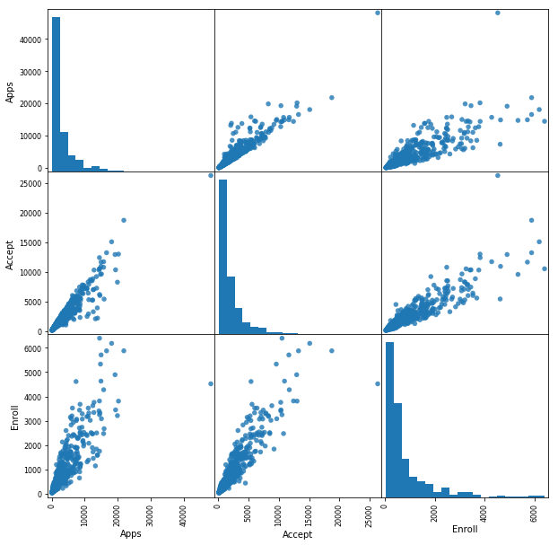

```python
scatter = pd.plotting.scatter_matrix(college[college.columns[2:5]], figsize=(10,10),
                                 marker='o', hist_kwds={'bins': 20}, s=30, alpha=.8)
plt.show()
```

#### iii.

**Use the `boxplot` attribute to produce side-by-side boxplots of `Room.Board` versus `Private`.**

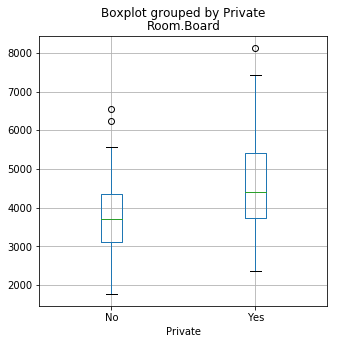

```python
box = college.boxplot(column='Room.Board', by='Private', figsize=(5,5))
```

#### iv.

**Create a new qualitative variable, called `Elite`, by binning the `Top10perc` variable. We are going to divide universities into two groups based on whether or not the proportion of students coming from the top 10% of their high school classes exceeds 50%. Use the describe attribute to see how many elite universities there are.**

```python
import numpy as np
Elite = np.array([False]*len(college))
Elite[college['Top10perc'] > 50] = True
college['Elite'] = pd.Series(Elite, index=college.index)
college.describe(include=['bool'])
```

|  | Elite |
| --- | --- |
| count | 777 |
| unique | 2 |
| top | False |
| freq | 699 |

**Now use the `boxplot` attribute to produce side-by-side boxplots of `Room.Board` versus `Elite`.**

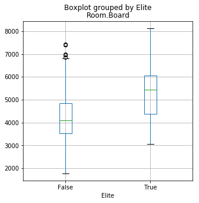

```python
box = college.boxplot(column='Room.Board', by='Elite', figsize=(5,5))
```

#### v.

**Use the `hist` attribute to produce some histograms with differing numbers of bins for a few of the quantitative variables.**

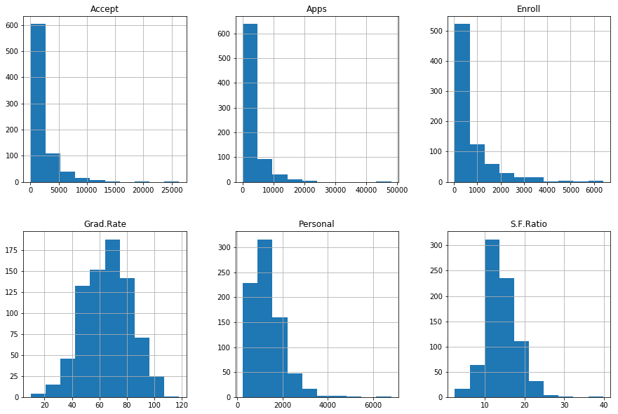

```python
hist = college.hist(column=['Apps','Accept','Enroll','Personal','S.F.Ratio','Grad.Rate'],
                    layout=(2,3), figsize=(15,10))
```

#### vi.

**Continue exploring the data, and provide a brief summary of what you discover.**

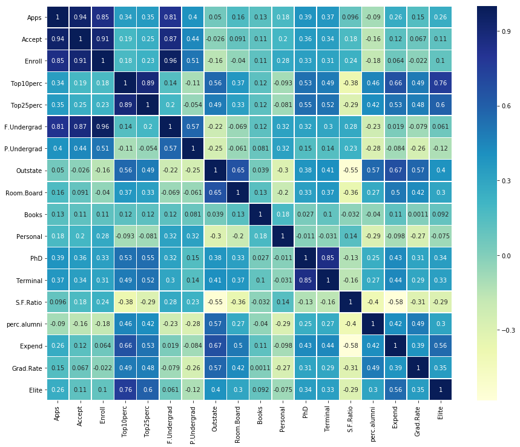

```python
import seaborn as sns
import matplotlib.pyplot as plt
fig = plt.figure(figsize=(15,12))
hp = sns.heatmap(college[college.columns[1:]].corr(), annot=True, cmap="YlGnBu", linewidths=.5)
```

1. There are strong positive linear correlations between or among variables:
   - `Apps`, `Accept`, `Enroll` and `F.Undergrad`
   - `Top10perc` and `Top25perc`
   - `PhD` and `Terminal`
2. There are moderate positive linear correlations between or among variables:
   - `Enroll` and `P.Undergrad`
   - `F.Undergrad` and `P.Undergrad`
   - `Top10perc`/`Top25perc` and `Outstate`
   - `Top10perc`/`Top25perc` and `PhD`
   - `Top10perc`/`Top25perc` and `Terminal`
   - `Top10perc`/`Top25perc`, `Expend` and `Elite`
   - `Outstate` and `Room.Board`
   - `Outstate` and `perc.alumni`
   - `Outstate` and `Expend`
   - `Outstate` and `Grad.Rate`
   - `Room.Board` and `Expend`
   - `perc.alumni` and `Grad.Rate`
3. There are moderate negative linear correlations between variables:
   - `S.F.Ratio` and `Outstate`
   - `S.F.Ratio` and `Expend`

Now let's explore more about student/faculty ratio and see if there are any fun facts. By making scatter plots for student/faculty ratio, we are able to see how student/faculty ratio affects out-of-state tuition and instructional expenditure. The predictor private is shown by colors.

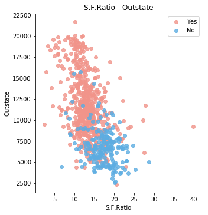

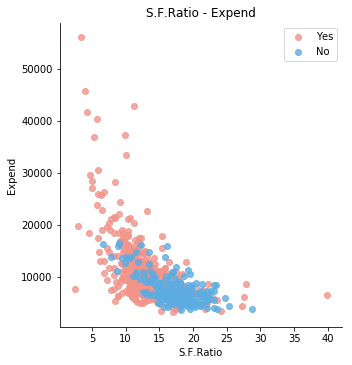

```python
import seaborn as sns
import matplotlib.pyplot as plt
scatter = sns.lmplot( x='S.F.Ratio', y='Outstate', data=college, fit_reg=False, hue='Private',
           legend=False, palette=dict(Yes='#F1948A', No='#5DADE2'))
l = plt.legend(loc='upper right')
t = plt.title('S.F.Ratio - Outstate')
scatter = sns.lmplot( x='S.F.Ratio', y='Expend', data=college, fit_reg=False, hue='Private',
           legend=False, palette=dict(Yes='#F1948A', No='#5DADE2'))
l = plt.legend(loc='upper right')
t = plt.title('S.F.Ratio - Expend')
```

By using the `seaborn.lmplot()` function to produce scatter plots for exploring `S.F.Ratio`, we can generally observe that:

1. Colleges with lower student/faculty ratio have higher out-of-state tuition.
2. Colleges with lower student/faculty ratio have higher instructional expenditure per student.
3. Most private colleges have low student/faculty ratio and students need to pay high out-of-state tuition and instructional expenditure.

Based on the above plots and observations, there can be two potential perspectives to further analyze this college data:

1. **Admission**: The number of applications received, the number of applicants accepted, the number of new students enrolled and the number of undergraduates are intercorrelated.
2. **College Profile**: The analysis for each college profile can be focused on the top students of high school class, student/faculty ratio, out-of-state tuition, instructional expenditure, student/faculty ratio, faculty excellence and graduation rate.

# 6

**This exercise involves the Auto data set found here: http://www-bcf.usc.edu/~gareth/ISL/Auto.data. Make sure that the missing values have been removed from the data.**

```python
auto = pd.read_csv('Auto.csv', sep=',', header=0)
auto['horsepower'] = pd.to_numeric(auto['horsepower'], errors='coerce')
auto = auto.dropna(axis=0)
```

### (a)

**Which of the predictors are quantitative, and which are qualitative?**

Quantitative predictors:

- mpg
- displacement
- horsepower
- weight
- acceleration
- year

Qualitative predictors:

- cylinders (ordinal: 3, 4, 5, 6, 8)
- origin (nomial: 1, 2, 3)
- name

Before moving to the next question, we use the `describe` attribute to produce a numerical summary of the variables in the data set.

```python
auto.describe()
```

|  | mpg | cylinders | displacement | horsepower | weight | acceleration | year | origin |
| --- | --- | --- | --- | --- | --- | --- | --- | --- |
| count | 392.000000 | 392.000000 | 392.000000 | 392.000000 | 392.000000 | 392.000000 | 392.000000 | 392.000000 |
| mean | 23.445918 | 5.471939 | 194.411990 | 104.469388 | 2977.584184 | 15.541327 | 75.979592 | 1.576531 |
| std | 7.805007 | 1.705783 | 104.644004 | 38.491160 | 849.402560 | 2.758864 | 3.683737 | 0.805518 |
| min | 9.000000 | 3.000000 | 68.000000 | 46.000000 | 1613.000000 | 8.000000 | 70.000000 | 1.000000 |
| 25% | 17.000000 | 4.000000 | 105.000000 | 75.000000 | 2225.250000 | 13.775000 | 73.000000 | 1.000000 |
| 50% | 22.750000 | 4.000000 | 151.000000 | 93.500000 | 2803.500000 | 15.500000 | 76.000000 | 1.000000 |
| 75% | 29.000000 | 8.000000 | 275.750000 | 126.000000 | 3614.750000 | 17.025000 | 79.000000 | 2.000000 |
| max | 46.600000 | 8.000000 | 455.000000 | 230.000000 | 5140.000000 | 24.800000 | 82.000000 | 3.000000 |

### (b)

**What is the range of each quantitative predictor?**

| predictor | min | max | range |
| --- | --- | --- | --- |
| mpg | 9 | 46.6 | 37.6 |
| displacement | 68 | 455 | 387 |
| horsepower | 46 | 230 | 184 |
| weight | 1613 | 5140 | 3527 |
| acceleration | 8 | 24.8 | 16.8 |
| year | 70 | 82 | 12 |

### (c)

**What is the mean and standard deviation of each quantitative predictor?**

| predictor | mean | std |
| --- | --- | --- |
| mpg | 23.445918 | 7.805007 |
| displacement | 194.411990 | 104.644004 |
| horsepower | 104.469388 | 38.491160 |
| weight | 2977.584184 | 849.402560 |
| acceleration | 15.541327 | 2.758864 |
| year | 75.979592 | 3.683737 |

### (d)

**Now remove the last 35 observations. What is the range, mean, and standard deviation of each quantitative predictor in the subset of the data that remains?**

```python
auto1 = auto[:-35]
auto1.describe()
```

|  | mpg | cylinders | displacement | horsepower | weight | acceleration | year | origin |
| --- | --- | --- | --- | --- | --- | --- | --- | --- |
| count | 357.000000 | 357.000000 | 357.000000 | 357.000000 | 357.000000 | 357.000000 | 357.000000 | 357.000000 |
| mean | 22.744538 | 5.565826 | 199.477591 | 106.442577 | 3018.467787 | 15.447059 | 75.403361 | 1.571429 |
| std | 7.606525 | 1.731810 | 106.868590 | 39.518879 | 868.021337 | 2.782504 | 3.341061 | 0.795755 |
| min | 9.000000 | 3.000000 | 68.000000 | 46.000000 | 1613.000000 | 8.000000 | 70.000000 | 1.000000 |
| 25% | 16.500000 | 4.000000 | 104.000000 | 76.000000 | 2230.000000 | 13.500000 | 73.000000 | 1.000000 |
| 50% | 21.500000 | 5.000000 | 156.000000 | 95.000000 | 2890.000000 | 15.400000 | 75.000000 | 1.000000 |
| 75% | 28.000000 | 8.000000 | 302.000000 | 133.000000 | 3672.000000 | 17.000000 | 78.000000 | 2.000000 |
| max | 46.600000 | 8.000000 | 455.000000 | 230.000000 | 5140.000000 | 24.800000 | 81.000000 | 3.000000 |

After removing the last 35 observations, the quantitative predictors in remaining subset of the data are summarized in the table below.

| predictor | min | max | range | mean | std |
| --- | --- | --- | --- | --- | --- |
| mpg | 9 | 46.6 | 37.6 | 22.744538 | 7.606525 |
| displacement | 68 | 455 | 387 | 199.477591 | 106.868590 |
| horsepower | 46 | 230 | 184 | 106.442577 | 39.518879 |
| weight | 1613 | 5140 | 3527 | 3018.467787 | 868.021337 |
| acceleration | 8 | 24.8 | 16.8 | 15.447059 | 2.782504 |
| year | 70 | 81 | 11 | 75.403361 | 3.341061 |

### (e)

**Using the full data set, investigate the predictors graphically, using scatterplots or other tools of your choice. Create some plots highlighting the relationships among the predictors. Comment on your findings.**

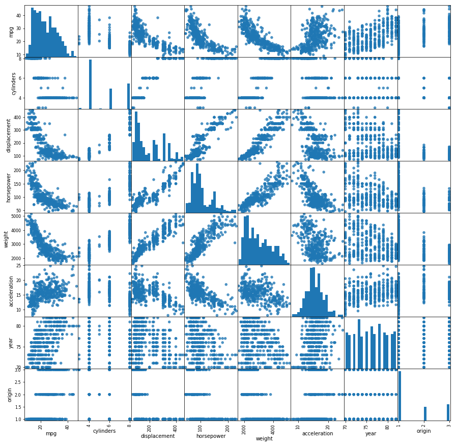

```python
scatter = pd.plotting.scatter_matrix(auto, figsize=(15,15), marker='o', hist_kwds={'bins': 20}, s=30, alpha=.8)
```

From the above scatter matrix showing the relationships among the predictors, we can find some linear relationships between predictors. For example:

1. `mpg` and `displacement`
2. `displacement` and `horsepower`
3. `horsepower` and `weight`

To find the Pearson correlation between predictors, we can create a heatmap.

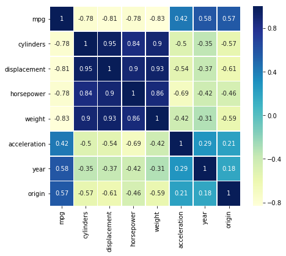

```python
import matplotlib.pyplot as plt
import seaborn as sns
fig = plt.figure(figsize=(7,6))
hp = sns.heatmap(auto[auto.columns[:8]].corr(), annot=True, cmap="YlGnBu",linewidths=.5)
```

By using the `seaborn.heatmap()` function to produce a correlation heatmap of the auto data, we can observe that:

### (f)

**Suppose that we wish to predict gas mileage (`mpg`) on the basis of the other variables. Do your plots suggest that any of the other variables might be useful in predicting `mpg`? Justify your answer.**

The plots above can bring suggestions about variables that might be useful in predicting `mpg`. From the scatter matrix and the heatmap, we can see the strong negative linear corelations between `mpg` and each of `cylinders`, `displacement`, `horsepower` and `weight`. We can address the hypothesis that increasing any of `cylinders`, `displacement`, `horsepower` and `weight` will lead a decrease in `mpg`. These four variables will be most useful in predicting `mpg`.